# CEU Data Analysis 4

Assignment 1

Cagdas Yetkin

2018-02-11

[figure not shown]

```r
library(doParallel)
library(ggplot2)
library(data.table)
library(caret)
library(glmnet)
library(ROCR)
library(dplyr)
library(ggthemes)
library(skimr)
library(gridExtra)
library(stargazer)
registerDoParallel(cores = 4)
```

## 1.

```r
data <- fread("airbnb_london_workfile.csv", stringsAsFactors = TRUE)
data[, c("neighbourhood_cleansed", "cancellation_policy",
         "price", "property_type", "room_type")  := NULL]
data[, neighbourhood_cleansed := NULL]
names(data)
```

```
 [1] "usd_cleaning_fee"          "f_property_type"           "f_room_type"
 [4] "f_cancellation_policy"     "f_bed_type"                "f_neighbourhood_cleansed"
 [7] "usd_price_day"             "p_host_response_rate"      "n_accommodates"
[10] "n_bathrooms"               "n_review_scores_rating"    "n_number_of_reviews"
[13] "n_guests_included"         "n_reviews_per_month"       "n_extra_people"
[16] "n_minimum_nights"          "n_beds"                    "n_days_since"
[19] "d_24hourcheckin"           "d_airconditioning"         "d_breakfast"
[22] "d_buzzerwirelessintercom"  "d_cabletv"                 "d_carbonmonoxidedetector"
[25] "d_cats"                    "d_dogs"                    "d_doorman"
[28] "d_doormanentry"            "d_dryer"                   "d_elevatorinbuilding"
[31] "d_essentials"              "d_familykidfriendly"       "d_fireextinguisher"
[34] "d_firstaidkit"             "d_freeparkingonpremises"   "d_freeparkingonstreet"
[37] "d_gym"                     "d_hairdryer"               "d_hangers"
[40] "d_heating"                 "d_hottub"                  "d_indoorfireplace"
[43] "d_internet"                "d_iron"                    "d_keypad"
[46] "d_kitchen"                 "d_laptopfriendlyworkspace" "d_lockonbedroomdoor"
[49] "d_lockbox"                 "d_otherpets"               "d_paidparkingoffpremises"
[52] "d_petsallowed"             "d_petsliveonthisproperty"  "d_pool"
[55] "d_privateentrance"         "d_privatelivingroom"       "d_safetycard"
[58] "d_selfcheckin"             "d_shampoo"                 "d_smartlock"
[61] "d_smokedetector"           "d_smokingallowed"          "d_suitableforevents"
[64] "d_tv"                      "d_washer"                  "d_washerdryer"
[67] "d_wheelchairaccessible"    "d_wirelessinternet"
```

```r
data[, usd_price_day := as.numeric(usd_price_day)]
```

Explore

```r
glimpse(data)
```

```
Observations: 51,697
Variables: 68
$ usd_cleaning_fee          <dbl> NA, NA, NA, NA, NA, NA, NA, NA, 25, NA, 20, 40, 10, 15, 10, NA, 10...
$ f_property_type           <fctr> Apartment, Apartment, Apartment, House, House, House, Apartment, ...
$ f_room_type               <fctr> Private room, Private room, Private room, Private room, Private r...
$ f_cancellation_policy     <fctr> flexible, moderate, flexible, flexible, flexible, flexible, flexi...
$ f_bed_type                <fctr> Real Bed, Couch, Real Bed, Real Bed, Real Bed, Real Bed, Real Bed...
$ f_neighbourhood_cleansed  <fctr> Kingston upon Thames, Kingston upon Thames, Kingston upon Thames,...
$ usd_price_day             <dbl> 168, 405, 179, 405, 190, 436, 284, 60, 476, 459, 321, 178, 260, 13...
$ p_host_response_rate      <int> 100, 100, NA, NA, 100, 100, 100, 90, 100, 47, NA, NA, 100, 100, NA...
$ n_accommodates            <int> 1, 2, 2, 2, 1, 2, 2, 5, 4, 4, 2, 10, 2, 2, 1, 2, 1, 2, 3, 2, 2, 7,...
$ n_bathrooms               <dbl> 1.0, 1.0, 1.0, 1.5, 1.0, 2.0, 1.0, 2.0, 1.0, 2.0, 1.5, 4.0, 0.5, 1...
$ n_review_scores_rating    <int> 100, 91, 80, NA, NA, 100, NA, 94, NA, NA, 90, 100, 98, 90, NA, 80,...
$ n_number_of_reviews       <int> 1, 15, 2, 0, 0, 2, 0, 10, 0, 0, 2, 1, 18, 6, 0, 2, 2, 4, 12, 1, 4,...
$ n_guests_included         <int> 1, 1, 1, 1, 1, 1, 1, 1, 1, 1, 1, 1, 1, 1, 1, 1, 1, 1, 1, 1, 1, 6, ...
```

[output cut: 55 more lines]

I tried PCA exploration to reduce dimentions but it was not useful: 80% of the variation was captured by 50 variables.

convert dummies to factor

```r
#dummies <- names(data)[grep("^d_.*",names(data))]
#setDT(data)[, (dummies):= lapply(.SD, factor), .SDcols=dummies]
```

```r
sapply(data, function(x) sum(is.na(x)))
```

```
         usd_cleaning_fee           f_property_type               f_room_type     f_cancellation_policy
                    20045                         0                         0                         0
               f_bed_type  f_neighbourhood_cleansed             usd_price_day      p_host_response_rate
                        0                         0                         0                     12880
           n_accommodates               n_bathrooms    n_review_scores_rating       n_number_of_reviews
                        0                       237                     16534                         0
        n_guests_included       n_reviews_per_month            n_extra_people          n_minimum_nights
                        0                     15774                         0                         0
                   n_beds              n_days_since           d_24hourcheckin         d_airconditioning
                      167                     15774                         0                         0
              d_breakfast  d_buzzerwirelessintercom                 d_cabletv  d_carbonmonoxidedetector
                        0                         0                         0                         0
                   d_cats                    d_dogs                 d_doorman            d_doormanentry
                        0                         0                         0                         0
                  d_dryer      d_elevatorinbuilding              d_essentials       d_familykidfriendly
                        0                         0                         0                         0
       d_fireextinguisher             d_firstaidkit   d_freeparkingonpremises     d_freeparkingonstreet
                        0                         0                         0                         0
                    d_gym               d_hairdryer                 d_hangers                 d_heating
                        0                         0                         0                         0
                 d_hottub         d_indoorfireplace                d_internet                    d_iron
                        0                         0                         0                         0
                 d_keypad                 d_kitchen d_laptopfriendlyworkspace       d_lockonbedroomdoor
                        0                         0                         0                         0
                d_lockbox               d_otherpets  d_paidparkingoffpremises             d_petsallowed
                        0                         0                         0                         0
 d_petsliveonthisproperty                    d_pool         d_privateentrance       d_privatelivingroom
                        0                         0                         0                         0
             d_safetycard             d_selfcheckin                 d_shampoo               d_smartlock
                        0                         0                         0                         0
          d_smokedetector          d_smokingallowed       d_suitableforevents                      d_tv
                        0                         0                         0                         0
                 d_washer             d_washerdryer    d_wheelchairaccessible        d_wirelessinternet
                        0                         0                         0                         0
```

```r
data <- data[data$usd_price_day > 10, ]
```

```r
data[, usd_cleaning_fee :=
       ifelse(is.na(usd_cleaning_fee), 0, usd_cleaning_fee)]
skim(data$usd_cleaning_fee)
```

```
Skim summary statistics

Variable type: numeric
              variable missing complete     n mean    sd p0 p25 median p75 p100     hist
 data$usd_cleaning_fee       0    51675 51675 22.9 32.24  0   0     15  35  517 ▇▁▁▁▁▁▁▁
```

```r
data[, n_bathrooms :=
       ifelse(is.na(n_bathrooms), median(n_bathrooms, na.rm = T), n_bathrooms)]
skim(data$n_bathrooms)
```

```
Skim summary statistics

Variable type: numeric
         variable missing complete     n mean   sd p0 p25 median p75 p100     hist
 data$n_bathrooms       0    51675 51675 1.26 0.53  0   1      1 1.5    8 ▇▂▁▁▁▁▁▁
```

```r
data[, n_beds :=
       ifelse(is.na(n_beds), n_accommodates, n_beds)]
skim(data$n_beds)
```

```
Skim summary statistics

Variable type: integer
    variable missing complete     n mean   sd p0 p25 median p75 p100     hist
 data$n_beds       0    51675 51675 1.71 1.17  0   1      1   2   16 ▇▁▁▁▁▁▁▁
```

dont impute the other NAs.

study your variables:

```r
sapply(data, function(x) if (class(x) == 'factor') {unique(x)
  } else if (class(x) != 'factor') {summary(x)})
```

```
$usd_cleaning_fee
   Min. 1st Qu.  Median    Mean 3rd Qu.    Max.
    0.0     0.0    15.0    22.9    35.0   517.0

$f_property_type
[1] Apartment House
Levels: Apartment House

$f_room_type
[1] Private room    Entire home/apt Shared room
Levels: Entire home/apt Private room Shared room

$f_cancellation_policy
[1] flexible moderate strict
Levels: flexible moderate strict

$f_bed_type
[1] Real Bed Couch
Levels: Couch Real Bed

$f_neighbourhood_cleansed
 [1] Kingston upon Thames   Croydon                Bromley                Hounslow
 [5] Ealing                 Havering               Hillingdon             Harrow
 [9] Brent                  Barnet                 Enfield                Waltham Forest
[13] Redbridge              Sutton                 Lambeth                Southwark
[17] Lewisham               Greenwich              Bexley                 Richmond upon Thames
[21] Merton                 Wandsworth             Hammersmith and Fulham Kensington and Chelsea
[25] City of London         Westminster            Camden                 Tower Hamlets
[29] Islington              Hackney                Haringey               Newham
[33] Barking and Dagenham
33 Levels: Barking and Dagenham Barnet Bexley Brent Bromley Camden City of London Croydon ... Westminster

$usd_price_day
   Min. 1st Qu.  Median    Mean 3rd Qu.    Max.
   11.0   120.0   303.0   296.3   459.0   576.0

$p_host_response_rate
   Min. 1st Qu.  Median    Mean 3rd Qu.    Max.    NA's
   0.00   97.00  100.00   92.58  100.00  100.00   12872

```

[output cut: 224 more lines]

```
$d_washer
   Min. 1st Qu.  Median    Mean 3rd Qu.    Max.
 0.0000  1.0000  1.0000  0.8416  1.0000  1.0000

$d_washerdryer
     Min.   1st Qu.    Median      Mean   3rd Qu.      Max.
0.0000000 0.0000000 0.0000000 0.0007934 0.0000000 1.0000000

$d_wheelchairaccessible
   Min. 1st Qu.  Median    Mean 3rd Qu.    Max.
0.00000 0.00000 0.00000 0.06473 0.00000 1.00000

$d_wirelessinternet
   Min. 1st Qu.  Median    Mean 3rd Qu.    Max.
  0.000   1.000   1.000   0.947   1.000   1.000
```

How does my price behave? Are my missing observations missing at random?

```r
#convert to numeric
#Transform the variable n_accommodates to numeric (in order to capture the order of the intervals)
data <- data[, n_accommodates := as.numeric(as.character(n_accommodates))]
```

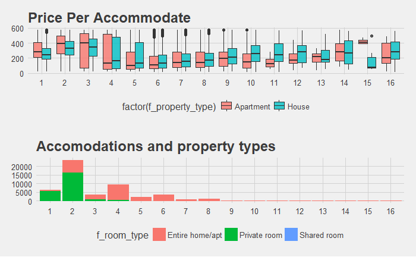

```r
plot1 <- ggplot(data, aes(x = factor(n_accommodates), y = usd_price_day, fill = factor(f_property_type))) +
         geom_boxplot(alpha=0.8) +
         scale_x_discrete(name = "Accomodate Persons") +
         ggtitle("Price Per Accommodate") + theme_fivethirtyeight()
plot2 <- ggplot(data = data) +
         geom_bar(data = data,
         aes(x = factor(n_accommodates),
         color = f_room_type, fill = f_room_type)) +
         ggtitle("Accomodations and property types") +
         xlab('Accommodates') + theme_fivethirtyeight()
grid.arrange(plot1, plot2, nrow=2)
```

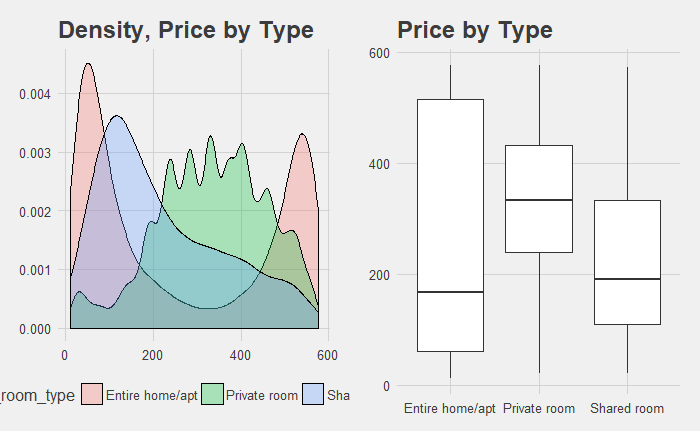

```r
## Distribution of price by room type
plot3 <- ggplot(data, aes(usd_price_day, fill = f_room_type)) +
         ggtitle("Density, Price by Type") +
         geom_density(alpha = 0.3) + theme_fivethirtyeight()
## Boxplot of price by room type
plot4 <- ggplot(data, aes(f_room_type, usd_price_day)) +
         ggtitle("Price by Type") +
         geom_boxplot()+ theme_fivethirtyeight()
grid.arrange(plot3, plot4, ncol=2)
```

These room types are totally different animals. Lets look at their boxplots.

```r
skim(data$usd_price_day)
```

```
Skim summary statistics

Variable type: numeric
           variable missing complete     n   mean    sd p0 p25 median p75 p100     hist
 data$usd_price_day       0    51675 51675 296.28 180.1 11 120    303 459  576 ▇▃▃▅▃▅▅▇
```

now see the missing observations

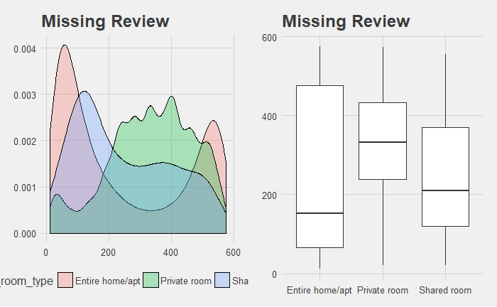

```r
## Distribution of price by room type for missing reviews
plot5 <- ggplot(data[is.na(n_reviews_per_month)], aes(usd_price_day, fill = f_room_type)) +
         ggtitle("Missing Review") +
         geom_density(alpha = 0.3) + theme_fivethirtyeight()
## Boxplot of price by room type
plot6 <- ggplot(data[is.na(n_reviews_per_month)], aes(f_room_type, usd_price_day)) +
         ggtitle("Missing Review") +
         geom_boxplot()+ theme_fivethirtyeight()
grid.arrange(plot5, plot6, ncol=2)
```

```r
## Distribution of price by room type for missing reviews
skim(data[is.na(n_reviews_per_month), ]$usd_price_day)
```

```
Skim summary statistics

Variable type: numeric
                                         variable missing complete     n   mean     sd p0 p25 median p75
 data[is.na(n_reviews_per_month), ]$usd_price_day       0    15759 15759 292.61 175.16 11 126    293 459
 p100     hist
  575 ▇▅▃▆▃▆▅▆
```

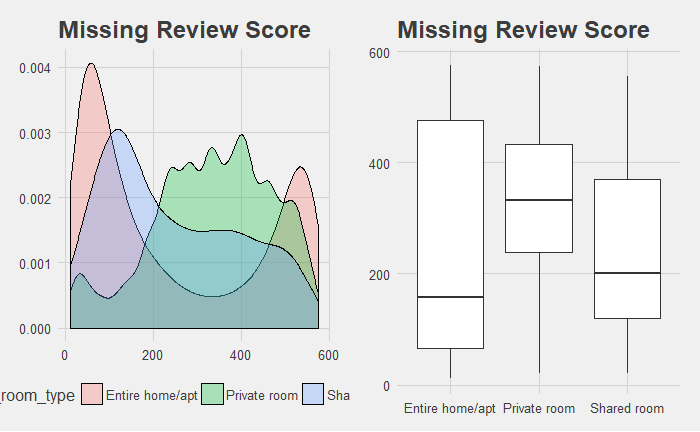

```r
## Distribution of price by room type for missing reviews
plot7 <- ggplot(data[is.na(n_review_scores_rating)], aes(usd_price_day, fill = f_room_type)) +
         ggtitle("Missing Review Score") +
         geom_density(alpha = 0.3) + theme_fivethirtyeight()
## Boxplot of price by room type
plot8 <- ggplot(data[is.na(n_review_scores_rating)], aes(f_room_type, usd_price_day)) +
         ggtitle("Missing Review Score") +
         geom_boxplot()+ theme_fivethirtyeight()
grid.arrange(plot7, plot8, ncol=2)
```

```r
## Distribution of price by room type for it
skim(data[is.na(n_review_scores_rating), ]$usd_price_day)
```

```
Skim summary statistics

Variable type: numeric
                                            variable missing complete     n   mean     sd p0 p25 median
 data[is.na(n_review_scores_rating), ]$usd_price_day       0    16519 16519 292.93 174.91 11 130    293
 p75 p100     hist
 459  575 ▇▅▃▆▃▆▅▆
```

```r
## Distribution of price by room type for host response rate
skim(data[is.na(p_host_response_rate), ]$usd_price_day)
```

```
Skim summary statistics

Variable type: numeric
                                          variable missing complete     n   mean     sd p0   p25 median
 data[is.na(p_host_response_rate), ]$usd_price_day       0    12872 12872 312.41 173.26 17 166.5    332
 p75 p100     hist
 459  573 ▇▃▃▆▅▇▆▇
```

We can see that missing observations for these variables are following the overall price distribution. We will drop these values with missing observation.

```r
data <- data %>%
          filter(!is.na(p_host_response_rate)) %>%
          filter(!is.na(n_review_scores_rating)) %>%
          filter(!is.na(n_reviews_per_month)) %>%
          filter(!is.na(n_days_since))
data <- data[complete.cases(data),]
```

Now time to forget about entire London and select a random district…

```r
#a dplyr way...
set.seed(22) #reproduce
selection_table <- data %>%
                      group_by(f_neighbourhood_cleansed) %>%
                      tally() %>%
                      filter(n > 1000) %>%
                      arrange(desc(n))
lottery_winner <- as.vector(sample(selection_table$f_neighbourhood_cleansed, 1))
lottery_winner
```

```
[1] "Camden"
```

Hello My District…

```r
district <- data %>%
              filter(f_neighbourhood_cleansed == lottery_winner)
```

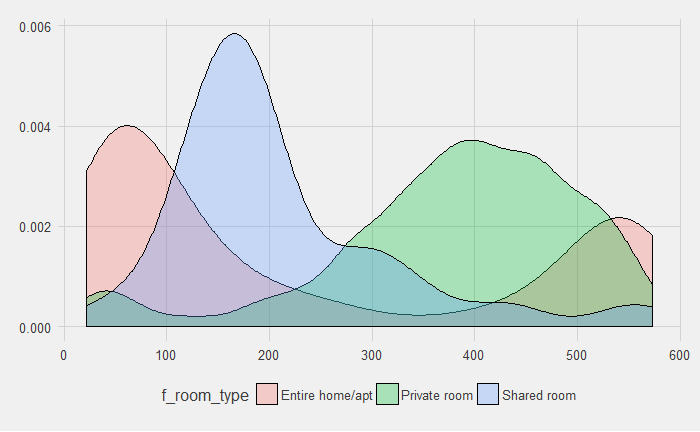

```r
## Distribution of price by room type
ggplot(district, aes(usd_price_day, fill = f_room_type)) +
  geom_density(alpha = 0.3) + theme_fivethirtyeight()
```

Its a kind of similar to entire London actually.

```r
skim(district$usd_price_day)
```

```
Skim summary statistics

Variable type: numeric
               variable missing complete    n   mean     sd p0 p25 median p75 p100     hist
 district$usd_price_day       0     2306 2306 280.96 198.65 22  77    284 476  573 ▇▃▂▂▂▃▃▆
```

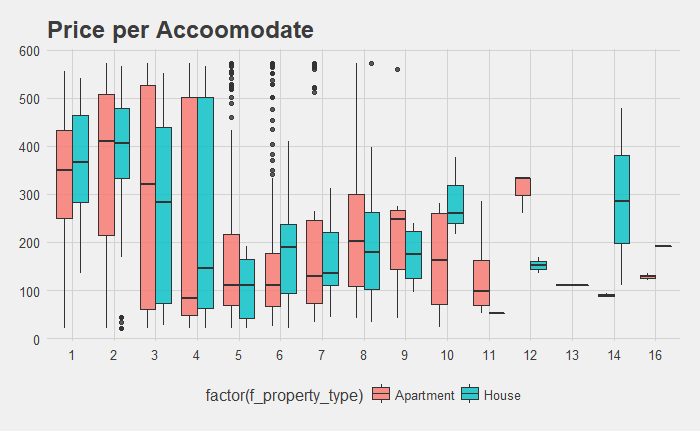

```r
ggplot(district, aes(x = factor(n_accommodates), y = usd_price_day, fill = factor(f_property_type))) +
        geom_boxplot(alpha=0.8) +
        scale_x_discrete(name = "Accomodate Persons") +
        ggtitle("Price per Accoomodate") + theme_fivethirtyeight()
```

```r
names(district)
```

```
 [1] "usd_cleaning_fee"          "f_property_type"           "f_room_type"
 [4] "f_cancellation_policy"     "f_bed_type"                "f_neighbourhood_cleansed"
 [7] "usd_price_day"             "p_host_response_rate"      "n_accommodates"
[10] "n_bathrooms"               "n_review_scores_rating"    "n_number_of_reviews"
[13] "n_guests_included"         "n_reviews_per_month"       "n_extra_people"
[16] "n_minimum_nights"          "n_beds"                    "n_days_since"
[19] "d_24hourcheckin"           "d_airconditioning"         "d_breakfast"
[22] "d_buzzerwirelessintercom"  "d_cabletv"                 "d_carbonmonoxidedetector"
[25] "d_cats"                    "d_dogs"                    "d_doorman"
[28] "d_doormanentry"            "d_dryer"                   "d_elevatorinbuilding"
[31] "d_essentials"              "d_familykidfriendly"       "d_fireextinguisher"
[34] "d_firstaidkit"             "d_freeparkingonpremises"   "d_freeparkingonstreet"
[37] "d_gym"                     "d_hairdryer"               "d_hangers"
[40] "d_heating"                 "d_hottub"                  "d_indoorfireplace"
[43] "d_internet"                "d_iron"                    "d_keypad"
[46] "d_kitchen"                 "d_laptopfriendlyworkspace" "d_lockonbedroomdoor"
[49] "d_lockbox"                 "d_otherpets"               "d_paidparkingoffpremises"
[52] "d_petsallowed"             "d_petsliveonthisproperty"  "d_pool"
[55] "d_privateentrance"         "d_privatelivingroom"       "d_safetycard"
[58] "d_selfcheckin"             "d_shampoo"                 "d_smartlock"
[61] "d_smokedetector"           "d_smokingallowed"          "d_suitableforevents"
[64] "d_tv"                      "d_washer"                  "d_washerdryer"
[67] "d_wheelchairaccessible"    "d_wirelessinternet"
```

These prices are not log normal. I will not use log price.

```r
## Distribution of salaries
#ggplot(district, aes(usd_price_day)) + geom_histogram()
#ggplot(district, aes(log(usd_price_day))) + geom_histogram()
#ggplot(district, aes(usd_price_day, usd_cleaning_fee)) + geom_point()
#ggplot(district, aes(p_host_response_rate, usd_price_day)) + geom_point()
#ggplot(district, aes(n_accommodates, usd_price_day)) + geom_point() + geom_jitter()
#ggplot(district, aes(n_bathrooms, usd_price_day)) + geom_point()+ geom_jitter()
#ggplot(district, aes(n_review_scores_rating, usd_price_day)) + geom_point()
#ggplot(district, aes(n_number_of_reviews, usd_price_day)) + geom_point()
```

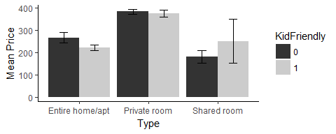

```r
#The most importand dummy variables will be plotted this way
#https://sakaluk.wordpress.com/2015/08/27/6-make-it-pretty-plotting-2-way-interactions-with-ggplot2/
library(psych)
dist_stats <- describeBy(district$usd_price_day,list(district$f_room_type,district$d_familykidfriendly), mat=TRUE,digits=2)
dist_stats$se = dist_stats$sd/sqrt(dist_stats$n)
names(dist_stats)[names(dist_stats) == 'group1'] = 'Type'
names(dist_stats)[names(dist_stats) == 'group2'] = 'KidFriendly'
limits = aes(ymax = mean + (1.96*se), ymin=mean - (1.96*se))
dodge = position_dodge(width=0.9)
apatheme=theme_bw()+
  theme(panel.grid.major=element_blank(),
        panel.grid.minor=element_blank(),
        panel.border=element_blank(),
        axis.line=element_line())
p1 <- ggplot(dist_stats, aes(x = Type, y = mean, fill = KidFriendly))+
  geom_bar(stat='identity', position=dodge)+
  geom_errorbar(limits, position=dodge, width=0.25)+
  ylab('Mean Price')+
  theme_fivethirtyeight() + apatheme +
  scale_fill_grey()
p1
```

```r
#library(gridExtra)
#plot1 <- qplot(iris$Sepal.Length)
#plot2 <- qplot(iris$Sepal.Width)
#grid.arrange(plot1, plot2, ncol=2)
```

```r
london <- data
```

```r
# Fit random forest: model
RFtrainControl <- trainControl(method = "cv",
                               number = 3,
                               verboseIter = TRUE)
set.seed(1234)
RFmodel <- train(
  usd_price_day ~ .,
  tuneLength = 2,
  data = district,
  method = 'ranger',
  #tuneGrid = data.frame(mtry = c(2, 20, 40, 60)),
  importance = 'impurity',
  trControl = RFtrainControl)
RFmodel
```

```
Random Forest

2306 samples
  67 predictor

No pre-processing
Resampling: Cross-Validated (3 fold)
Summary of sample sizes: 1537, 1538, 1537
Resampling results across tuning parameters:

  mtry  splitrule   RMSE      Rsquared   MAE
    2   variance    186.6058  0.2363015  167.5057
    2   extratrees  190.7160  0.1947029  172.6978
  100   variance    168.5999  0.2814072  131.1261
  100   extratrees  168.2517  0.2852625  133.1674

Tuning parameter 'min.node.size' was held constant at a value of 5
RMSE was used to select the optimal model using the smallest value.
The final values used for the model were mtry = 100, splitrule = extratrees and min.node.size = 5.
```

```r
names(RFmodel$modelInfo)
```

```
 [1] "label"      "library"    "check"      "loop"       "type"       "parameters" "grid"
 [8] "fit"        "predict"    "prob"       "predictors" "varImp"     "levels"     "oob"
[15] "tags"       "sort"
```

```r
varImp(RFmodel)
```

```
ranger variable importance

  only 20 most important variables shown (out of 100)

                         Overall
f_room_typePrivate room   100.00
n_accommodates             49.20
n_beds                     47.76
usd_cleaning_fee           45.33
n_reviews_per_month        33.36
n_number_of_reviews        25.90
n_days_since               24.25
n_review_scores_rating     22.76
d_dryer                    19.74
n_extra_people             19.66
n_minimum_nights           19.41
n_guests_included          18.23
d_elevatorinbuilding       17.17
d_tv                       16.22
n_bathrooms                15.41
d_fireextinguisher         15.41
d_cabletv                  15.21
p_host_response_rate       14.78
d_carbonmonoxidedetector   14.21
d_buzzerwirelessintercom   14.06
```

These seem to be my most important variables. I will try them in my linear models.

Partitioning the data to 70% training and 30% test samples.

```r
my_ratio <- 0.7
#First for the entire London
set.seed(123)
train_indices_london <- createDataPartition(y = london[["usd_price_day"]],
                                     times = 1,
                                     p = my_ratio,
                                     list = FALSE)
data_train_london <- london[train_indices_london, ]
data_test_london  <- london[-train_indices_london, ]
#Now for the selected district
set.seed(123)
train_indices_district <- createDataPartition(y = district[["usd_price_day"]],
                                     times = 1,
                                     p = my_ratio,
                                     list = FALSE)
data_train_district <- district[train_indices_district, ]
data_test_district  <- district[-train_indices_district, ]
```

```r
train_control <- trainControl(method = "cv", number = 10)
#tune_grid <- data.frame("cp" = c(0.01, 0.001, 0.0001, 0.00001))
```

```r
# Linear 1
set.seed(1234)
model_1_london <- train(usd_price_day ~ n_accommodates,
                   data = data_train_london,
                   method = "lm",
                   trControl = train_control)
model_1_london$results[["RMSE"]]
```

```
[1] 177.6739
```

```r
set.seed(1234)
model_1_district <- train(usd_price_day ~ n_accommodates,
                   data = data_train_district,
                   method = "lm",
                   trControl = train_control)
#model_1_district$results[["RMSE"]]
```

```r
resamps <- resamples(list("model_1_london" = model_1_london,
                          "model_1_district" = model_1_district))
summary(resamps)
```

```
Call:
summary.resamples(object = resamps)

Models: model_1_london, model_1_district
Number of resamples: 10

MAE
                     Min.  1st Qu.   Median     Mean  3rd Qu.     Max. NA's
model_1_london   151.2778 153.4596 154.6152 154.3656 154.9560 156.4442    0
model_1_district 163.1043 165.4899 167.3010 167.4403 169.9582 170.6805    0

RMSE
                     Min.  1st Qu.   Median     Mean  3rd Qu.     Max. NA's
model_1_london   174.7647 177.2355 177.7837 177.6739 178.4516 179.4521    0
model_1_district 183.8954 186.5389 189.1208 189.4404 191.7144 196.6656    0

Rsquared
                       Min.    1st Qu.     Median       Mean    3rd Qu.       Max. NA's
model_1_london   0.05516830 0.05927730 0.06199725 0.06376730 0.06434448 0.08434502    0
model_1_district 0.04147129 0.07920504 0.08254175 0.08836093 0.10421449 0.13836470    0
```

they are performing almost the same on test sets:

```r
#postResample(data_test_district$usd_price_day, predict(model_1_district, data_test_district))
#postResample(data_test_london$usd_price_day, predict(model_1_london, data_test_london))
test_prediction_district <- predict.train(model_1_district, newdata = data_test_district)
test_prediction_london <- predict.train(model_1_london, newdata = data_test_london)
cat('District RMSE: ', RMSE(test_prediction_district, data_test_district[["usd_price_day"]]),
    'London RMSE: ',   RMSE(test_prediction_london, data_test_london[["usd_price_day"]]))
```

```
District RMSE:  188.409 London RMSE:  177.3849
```

```r
# Linear 2
#sapply(data_train_london, function(x) sum(is.na(x)))
set.seed(1234)
model_2_london <- train(usd_price_day ~ n_accommodates + f_room_type + n_beds + n_bathrooms +
                          f_property_type + f_bed_type + d_familykidfriendly,
                   data = data_train_london,
                   method = "lm",
                   trControl = train_control)
                   #preProcess=c("center", "scale"))
#model_1_london$results[["RMSE"]]
set.seed(1234)
model_2_district <- train(usd_price_day ~ n_accommodates + f_room_type + n_beds + n_bathrooms +
                          f_property_type + f_bed_type + d_familykidfriendly,
                   data = data_train_district,
                   method = "lm",
                   trControl = train_control)
                   #preProcess=c("center", "scale"))
#model_1_district$results[["RMSE"]]
```

```r
resamps <- resamples(list("model_2_london" = model_2_london,
                          "model_2_district" = model_2_district))
summary(resamps)
```

```
Call:
summary.resamples(object = resamps)

Models: model_2_london, model_2_district
Number of resamples: 10

MAE
                     Min.  1st Qu.   Median     Mean  3rd Qu.     Max. NA's
model_2_london   151.0579 152.4312 152.6248 152.6164 153.1731 153.7292    0
model_2_district 147.4670 154.5047 158.5852 157.0105 159.1721 162.9940    0

RMSE
                     Min.  1st Qu.   Median     Mean  3rd Qu.     Max. NA's
model_2_london   174.0014 175.9106 176.6983 176.3599 177.0580 177.6322    0
model_2_district 171.9963 180.6537 183.9679 183.1996 186.0742 192.2049    0

Rsquared
                       Min.    1st Qu.     Median       Mean    3rd Qu.       Max. NA's
model_2_london   0.05929525 0.06799848 0.07653588 0.07640299 0.08344415 0.09632488    0
model_2_district 0.08485104 0.12067207 0.15156637 0.14715142 0.16016544 0.25447324    0
```

they are performing almost the same on test sets:

```r
#postResample(data_test_district$usd_price_day, predict(model_1_district, data_test_district))
#postResample(data_test_london$usd_price_day, predict(model_1_london, data_test_london))
test_prediction_district <- predict.train(model_2_district, newdata = data_test_district)
test_prediction_london <- predict.train(model_2_london, newdata = data_test_london)
cat('District RMSE: ', RMSE(test_prediction_district, data_test_district[["usd_price_day"]]),
    'London RMSE: ',   RMSE(test_prediction_london, data_test_london[["usd_price_day"]]))
```

```
District RMSE:  182.962 London RMSE:  175.9923
```

```r
# Linear 3
# Factor values
#X1  <- c("f_room_type*f_property_type",  "n_number_of_reviews*f_property_type")
# Interactions of factors and dummies
#X2  <- c("d_airconditioning*f_property_type", "d_cats*f_property_type", "d_dogs*f_property_type")
set.seed(1234)
model_3_london <- train(usd_price_day ~ n_accommodates + f_room_type + n_beds + n_bathrooms +
                          f_property_type + f_bed_type + d_familykidfriendly +
                          f_room_type*f_property_type +  n_number_of_reviews*f_property_type +
                          d_airconditioning*f_property_type +
                          d_cats*f_property_type + d_dogs*f_property_type +
                          d_familykidfriendly*f_property_type,
                   data = data_train_london,
                   method = "lm",
                   trControl = train_control)
                   #preProcess=c("center", "scale"))
#model_1_london$results[["RMSE"]]
set.seed(1234)
model_3_district <- train(usd_price_day ~ n_accommodates + f_room_type + n_beds + n_bathrooms +
                          f_property_type + f_bed_type + d_familykidfriendly +
                          f_room_type*f_property_type +  n_number_of_reviews*f_property_type +
                          d_airconditioning*f_property_type +
                          d_cats*f_property_type + d_dogs*f_property_type +
                          d_familykidfriendly*f_property_type,
                   data = data_train_district,
                   method = "lm",
                   trControl = train_control)
```

[output not shown]

```r
                   #preProcess=c("center", "scale"))
#model_1_district$results[["RMSE"]]
```

```r
resamps <- resamples(list("model_3_london" = model_3_london,
                          "model_3_district" = model_3_district))
summary(resamps)
```

```
Call:
summary.resamples(object = resamps)

Models: model_3_london, model_3_district
Number of resamples: 10

MAE
                     Min.  1st Qu.   Median     Mean  3rd Qu.     Max. NA's
model_3_london   150.3521 151.6616 152.1745 151.9966 152.4419 153.7317    0
model_3_district 144.7918 156.3277 157.4324 156.3888 158.6256 161.4246    0

RMSE
                     Min.  1st Qu.   Median     Mean  3rd Qu.     Max. NA's
model_3_london   173.4972 175.2337 176.2972 175.9992 176.8722 177.5118    0
model_3_district 170.2303 181.5329 183.7219 182.6587 184.5698 190.4162    0

Rsquared
                       Min.    1st Qu.     Median       Mean    3rd Qu.      Max. NA's
model_3_london   0.06469492 0.06933276 0.08201954 0.08032248 0.08926465 0.1017325    0
model_3_district 0.10031789 0.13483652 0.14487591 0.15195052 0.15912628 0.2664326    0
```

```r
#postResample(data_test_district$usd_price_day, predict(model_1_district, data_test_district))
#postResample(data_test_london$usd_price_day, predict(model_1_london, data_test_london))
test_prediction_district <- predict.train(model_3_district, newdata = data_test_district)
```

```
prediction from a rank-deficient fit may be misleading
```